# 第五B單元：基礎統計 with R

中山大學管理學院 卓雍然

2019-03-18 22:04:26

**單元摘要：**使用R複習並練習操作「基礎統計」

- 統計量 Statistics
  - 基本的統計量(函數)
- R內建的機率分布與其功能函數
  - 機率分布與功能函數
- 常見的連續的機率分布 Continuous Probability Distributions
  - 常態分布 Normal Distributions
  - 卡方分布 Chi-Square Distribution
  - F分布 F Distribution
  - Student-$t$ Distribution
  - Uniform Distribution
- 常見的離散的機率分布 Discrete Probability Distributions
  - 二項分布 Binomial Dist.
  - 超幾何分布 Hypergeometric Dist.
  - 布瓦松分布 Poisson Dist.
  - 幾何分布 Geometric Dist.
  - 負二項分布 Negative Binominal Dist.
  - 多項分布 Multinomial Dist.
- 機率分布的應用
  - Applications of Normal Dist.
  - Applications of Poisson Dist.

```r
pacman::p_load(dplyr)
```

### 【A】統計量 Statistics

統計量(statistics)就是一群數值的摘要(summary)，常用的統計量有：

- 平均值 Mean：`mean()`
- 中位數：`median()`
- 最大值：`max()`
- 最小值：`min()`
- 標準差 Std. Deviation：`sd()`
- 變異數 Variance：`var()`
- 百分位：`quantile()`

我們先隨機在零到一之間產生50個的亂數

```r
X = runif(50)
X
```

```
 [1] 0.9834267 0.8718041 0.3447268 0.0388816 0.3455273 0.8549113 0.1554299
 [8] 0.9974897 0.7569569 0.5310693 0.0101474 0.4771000 0.1449454 0.0026086
[15] 0.7096724 0.8793654 0.0132889 0.5378332 0.3045127 0.5483006 0.1333062
[22] 0.6215871 0.3976403 0.7872535 0.8287441 0.6226134 0.9297962 0.7812474
[29] 0.4194055 0.0038438 0.1340284 0.5566362 0.3275156 0.2804389 0.7868582
[36] 0.5970529 0.7952426 0.2761536 0.0229424 0.0619646 0.3071907 0.5687597
[43] 0.5538912 0.2262658 0.3171824 0.9138010 0.3009228 0.6924112 0.3468240
[50] 0.1396425
```

```r
summary(X)
```

```
   Min. 1st Qu.  Median    Mean 3rd Qu.    Max.
0.00261 0.23874 0.44825 0.46478 0.74514 0.99749
```

```r
c(sd(X), var(X))
```

```
[1] 0.303387 0.092044
```

```r
quantile(X, seq(0,1,1/10))
```

```
       0%       10%       20%       30%       40%       50%       60%       70%
0.0026086 0.0372877 0.1438848 0.2947776 0.3378423 0.4482528 0.5549892 0.6435527
      80%       90%      100%
0.7869373 0.8725602 0.9974897
```

除了這些統計量之外，我們也可以利用圖形來幫助我們(對於這一群數字)建立一個整體性的認識

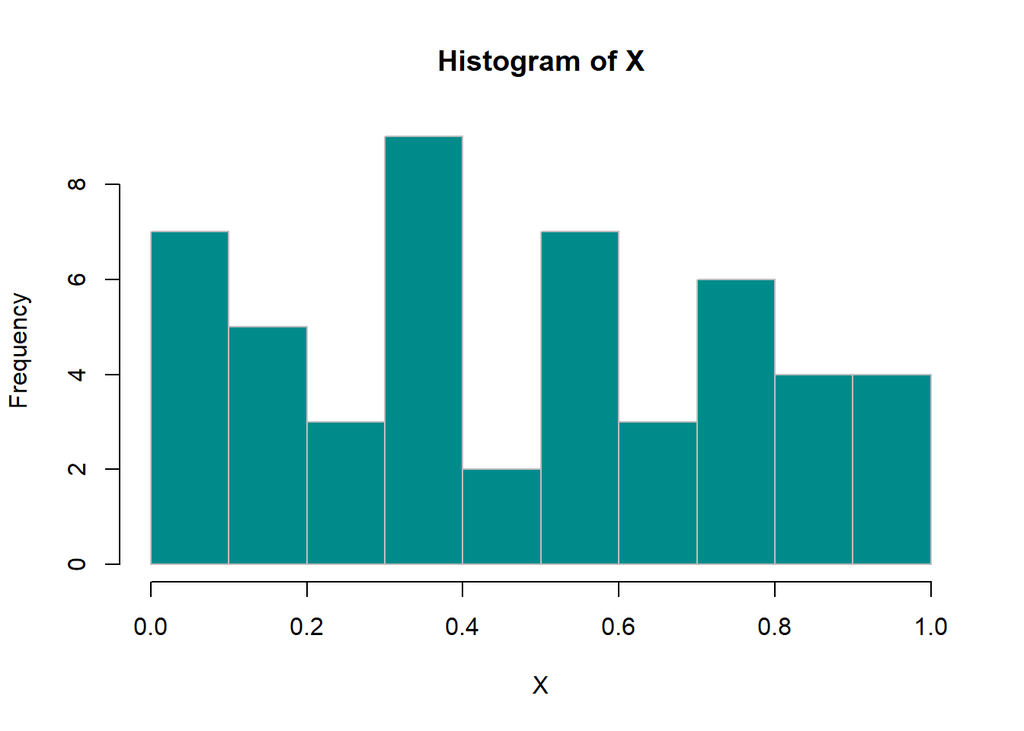

```r
hist(X, 10, col='darkcyan', border='gray')
```

### 【B】R內建的機率分布與其功能函數

R有一群內建的機率分布

- beta : `dbeta()`
- binomial : `dbinom()`
- Cauchy : `dcauchy()`
- chi-squared : `dchisq()`
- exponential : `dexp()`
- F : `df()`
- gamma : `dgamma()`
- geometric : `dgeom
- hypergeometric : `dhyper()`
- log-normal : `dlnorm()`
- multinomial : `dmultinom()`
- negative binomial : `dnbinom()`
- normal : `dnorm()`
- Poisson : `dpois()`
- Student’s t : `dt()`
- uniform : `dunif()`
- Weibull : `dweibull()`
- …其他幾乎所有叫得出名字的機率分布都可以透過套件外掛

```r
?distributions
```

每一種機率分布都有四個功能函數：

- `d<name>()` : density or probability function
- `p<name>()` : cumulative density function
- `q<name>()` : quantile function
- `r<name>()` : random sampling

##### B1. `d<name>: d for density` 機率密度函數 (PDF)

`d<name>`用來求取對應到某一數值的機率密度， 給定機率分佈的種類和它所需要的「參數」，我們就能確定「值域」之中每一點的機率密度； `d<name>`通常用來畫機率密度函數

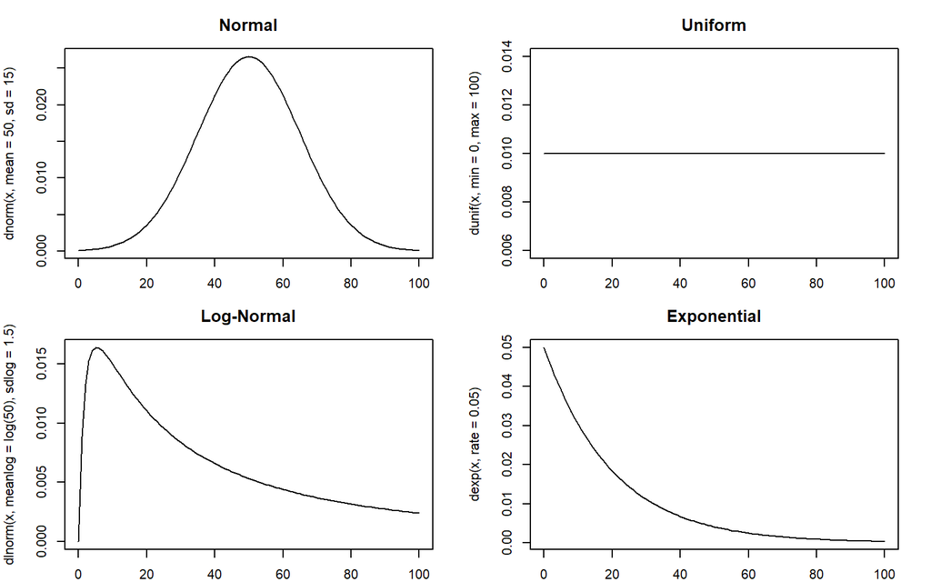

```r
par(mfrow=c(2,2), mar=c(2,4,3,2), cex=0.7)
curve(dnorm(x,mean=50,sd=15),0,100,main="Normal")
curve(dunif(x,min=0,max=100),0,100,main="Uniform")
curve(dlnorm(x,meanlog=log(50),sdlog=1.5),0,100,main="Log-Normal")
curve(dexp(x,rate=0.05),0,100,main="Exponential")
```

```r
dnorm(x=40, mean=50, sd=15)
```

```
[1] 0.021297
```

```r
dnorm(seq(0,100,20), mean=50, sd=15)
```

```
[1] 0.00010282 0.00359940 0.02129653 0.02129653 0.00359940 0.00010282
```

畫出機率分布的形狀

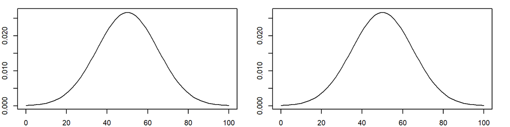

```r
par(mfrow=c(1,2), mar=c(2,2,1,2),cex=0.7)
x = seq(0,100,1)
y = dnorm(x, mean=50, sd=15)
plot(x, y, type='l')
# curve() is a easier way to plot a function (or expresion) of x
curve(dnorm(x,mean=50,sd=15),0,100)
```

##### B2. `r<name>: r for random` 隨機抽樣

`r<name>`常用來從給定的機率分佈之中隨機抽出樣本

```r
norm50 = rnorm(n=50, mean=50, sd=10)
unif50 = runif(n=50, min=0, max=100)
```

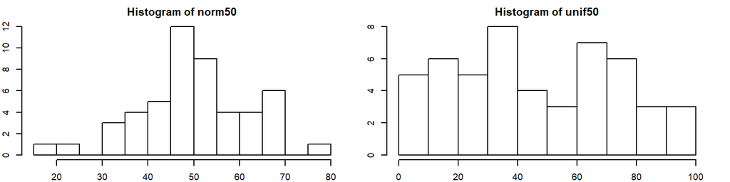

```r
par(mfrow=c(1,2), mar=c(2,2,2,2),cex=0.6)
hist(norm50,breaks=10)
hist(unif50,breaks=10)
```

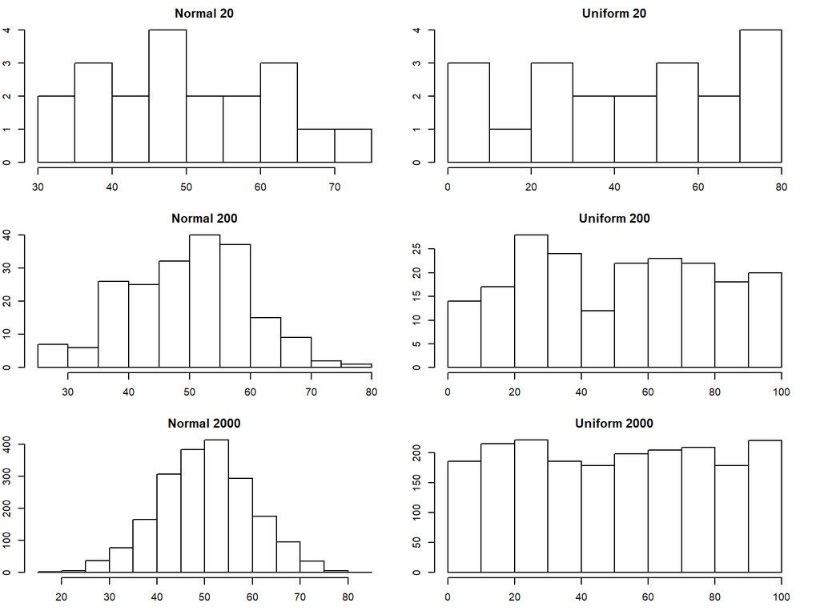

```r
par(mfrow=c(3,2), mar=c(3,2,2,2),cex=0.6)
for(n in c(20, 200, 2000)) {
  hist(rnorm(n, mean=50, sd=10),breaks=10,main=paste("Normal",n))
  hist(runif(n, min=0, max=100),breaks=10,main=paste("Uniform",n))
  }
```

##### B3. `p<name>: p for probability` 累積機率函數 (CDF)

`p<name>`求取變數落在某數值區間的機率，給定機率分佈，我們常會想要知道目標變數會落在某一個數值空間的機率，如果隨機變數`X ~ Normal[mu=50, sd=10]`，`pnorm(x=55, 50, 10)`會傳回`X < 55`的機率；

```r
mu=50; sd=10
pnorm(55, mu, sd)
```

```
[1] 0.69146
```

```r
x1 = 90; x2 = 130
p1 = pnorm(x1,100,20); p2 = pnorm(x2,100,20)
c(p1, p2 - p1, 1 - p2)
```

```
[1] 0.308538 0.624655 0.066807
```

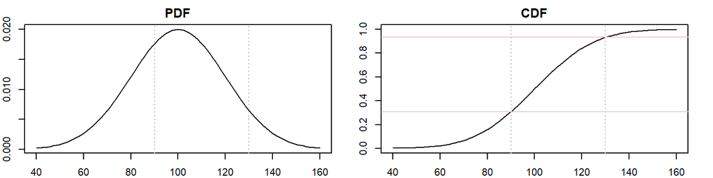

```r
par(mfrow=c(1,2), mar=c(2,2,2,2),cex=0.7)
curve(dnorm(x,100,20),40,160,main="PDF")
abline(v=c(x1,x2),col='gray',lty=3)
curve(pnorm(x,100,20),40,160,main="CDF")
abline(v=c(x1,x2),col='gray',lty=3)
abline(h=c(p1,p2),col='pink')
```

##### B4. `q<name>: q for quantile` 百分位函數

`q<name>`通常用來求取對應到某一機率的臨界值，如果隨機變數`X ~ Normal[mu, sd]`，`qnorm(p=0.8, mu, sd)`會傳回`Pr[X < x1] = 0.8`的臨界值`x1`；

```r
qnorm(p=0.8, 100, 20)
```

```
[1] 116.83
```

🗿 問題討論：  
A. 如果隨機變數`X ~ Normal[mu=100, sd=20]`，請求`X`的90%信賴區間  
B. 請畫出圖形來解釋你的運算

```r
interval = c(0.05, 0.95)
Q = qnorm(interval, 100, 20); Q
```

```
[1]  67.103 132.897
```

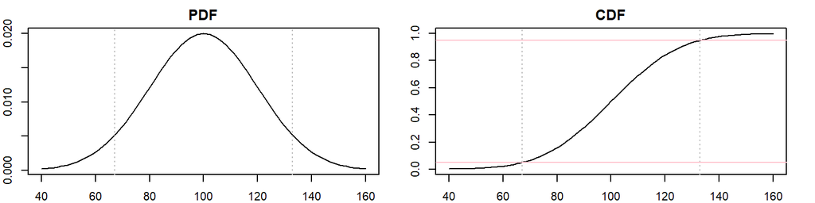

```r
curve(dnorm(x,100,20),40,160,main="PDF")
abline(v=c(Q[1],Q[2]),col='gray',lty=3)
curve(pnorm(x,100,20),40,160,main="CDF")
abline(v=c(Q[1],Q[2]),col='gray',lty=3)
abline(h=interval,col='pink')
```